# Final Project

by *Ryan Blackmore*

This notebook is for the final project of the 'Statistics for Data Science with Python' course on Coursera. Each section shall be broken down as much as possible by Task. The main questions that I need to answer are as follows:

- Is there a significant difference in the median value of houses bounded by the Charles river or not?
- Is there a difference in median values of houses of each proportion of owner-occupied units built before 1940?
- Can we conclude that there is no relationship between Nitric oxide concentrations and the proportion of non-retail business acres per town?
- What is the impact of an additional weighted distance to the five Boston employment centres on the median value of owner-occupied homes?

## Task 1: Familiarize yourself with the Data

The following describes the dataset variables:

- CRIM - per capita crime rate by town
- ZN - proportion of residential land zoned for lots over 25,000 sq.ft.
- INDUS - proportion of non-retail business acres per town.
- CHAS - Charles River dummy variable (1 if tract bounds river; 0 otherwise)
- NOX - nitric oxides concentration (parts per 10 million)
- RM - average number of rooms per dwelling
- AGE - proportion of owner-occupied units built prior to 1940
- DIS - weighted distances to five Boston employment centres
- RAD - index of accessibility to radial highways
- TAX - full-value property-tax rate per \$ 10,000
- PTRATIO - pupil-teacher ratio by town
- LSTAT - % lower status of the population
- MEDV - Median value of owner-occupied homes in $1000's

## Task 2: Getting an IBM Watson Studio account

Done

## Task 3: Load in the Dataset in your Jupyter Notebook

In this section, the code for downloading the data was provided so that wasn't an issue. The code is below and the database that is produced from the url.

```python
import pandas as pd

boston_url = 'https://cf-courses-data.s3.us.cloud-object-storage.appdomain.cloud/IBMDeveloperSkillsNetwork-ST0151EN-SkillsNetwork/labs/boston_housing.csv'
boston_df=pd.read_csv(boston_url)
boston_df
```

|  | Unnamed: 0 | CRIM | ZN | INDUS | CHAS | NOX | RM | AGE | DIS | RAD | TAX | PTRATIO | LSTAT | MEDV |
| --- | --- | --- | --- | --- | --- | --- | --- | --- | --- | --- | --- | --- | --- | --- |
| 0 | 0 | 0.00632 | 18.0 | 2.31 | 0.0 | 0.538 | 6.575 | 65.2 | 4.0900 | 1.0 | 296.0 | 15.3 | 4.98 | 24.0 |
| 1 | 1 | 0.02731 | 0.0 | 7.07 | 0.0 | 0.469 | 6.421 | 78.9 | 4.9671 | 2.0 | 242.0 | 17.8 | 9.14 | 21.6 |
| 2 | 2 | 0.02729 | 0.0 | 7.07 | 0.0 | 0.469 | 7.185 | 61.1 | 4.9671 | 2.0 | 242.0 | 17.8 | 4.03 | 34.7 |
| 3 | 3 | 0.03237 | 0.0 | 2.18 | 0.0 | 0.458 | 6.998 | 45.8 | 6.0622 | 3.0 | 222.0 | 18.7 | 2.94 | 33.4 |
| 4 | 4 | 0.06905 | 0.0 | 2.18 | 0.0 | 0.458 | 7.147 | 54.2 | 6.0622 | 3.0 | 222.0 | 18.7 | 5.33 | 36.2 |
| ... | ... | ... | ... | ... | ... | ... | ... | ... | ... | ... | ... | ... | ... | ... |
| 501 | 501 | 0.06263 | 0.0 | 11.93 | 0.0 | 0.573 | 6.593 | 69.1 | 2.4786 | 1.0 | 273.0 | 21.0 | 9.67 | 22.4 |
| 502 | 502 | 0.04527 | 0.0 | 11.93 | 0.0 | 0.573 | 6.120 | 76.7 | 2.2875 | 1.0 | 273.0 | 21.0 | 9.08 | 20.6 |
| 503 | 503 | 0.06076 | 0.0 | 11.93 | 0.0 | 0.573 | 6.976 | 91.0 | 2.1675 | 1.0 | 273.0 | 21.0 | 5.64 | 23.9 |
| 504 | 504 | 0.10959 | 0.0 | 11.93 | 0.0 | 0.573 | 6.794 | 89.3 | 2.3889 | 1.0 | 273.0 | 21.0 | 6.48 | 22.0 |
| 505 | 505 | 0.04741 | 0.0 | 11.93 | 0.0 | 0.573 | 6.030 | 80.8 | 2.5050 | 1.0 | 273.0 | 21.0 | 7.88 | 11.9 |

506 rows × 14 columns

Next I will import the other important packages and libaries.

```python
import scipy as sp
import requests as rq
import seaborn as sb
import numpy as np
```

## Task 4: Generate Descriptive Statistics and Visualizations

The instructions for the next section are as follows:-

For all visualizations, please include a title in each graph and appropriate labels Generate the following and explain your findings:

- For the "Median value of owner-occupied homes" provide a boxplot
- Provide a bar plot for the Charles river variable
- Provide a boxplot for the MEDV variable vs the AGE variable. (Discretize the age variable into three groups of 35 years and younger, between 35 and 70 years and 70 years and older)
- Provide a scatter plot to show the relationship between Nitric oxide concentrations and the proportion of non-retail business acres per town. What can you say about the relationship?
- Create a histogram for the pupil to teacher ratio variable

### Median Value of owner-occupied homes

```
Max:  50.0
Min:  5.0
Median:  21.2
```

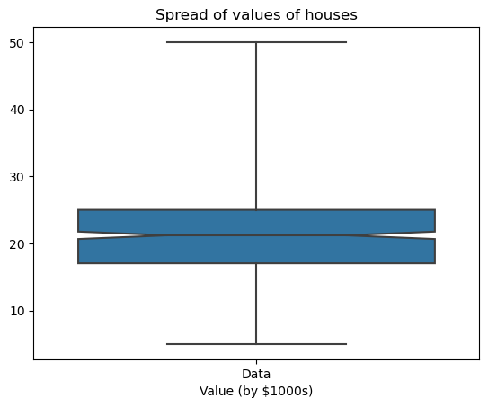

```python
medv = boston_df['MEDV']
medv_dic = {"Data":medv}
medv_df = pd.DataFrame(medv_dic)
medv_df
graph1 = (sb.boxplot(data= medv_df, notch = True, showcaps= True, whis=100).set(xlabel ="Value (by $1000s)", title= "Spread of values of houses"))

print("Max: ", medv.max())
print("Min: ", medv.min())
print("Median: ", medv.median())
```

```python
print("Min: ", medv_df['Data'].min())
print("Quartiles:-\n", medv_df['Data'].quantile([0,0.25, 0.5, 0.75,1]))
print("Max: ", medv_df['Data'].max())
```

```
Min:  5.0
Quartiles:-
 0.00     5.000
0.25    17.025
0.50    21.200
0.75    25.000
1.00    50.000
Name: Data, dtype: float64
Max:  50.0
```

[output not shown]

Analysis:

- Half of the houses describes by the data have a value of between \$17,025 and \\$25,000
- The lower 25% of houses only range between \$5,000 and \\$17,025
- The higher 25% of houses range from \$25,000 and \\$50,000
- Therefore 75% of the houeses are worth less than half of the most expensive house in the dataset.

### Provide a bar plot for the Charles river variable

For this task I will need the CHAS variable. In addition, I will need to create a new table to summarise the information I am needing.

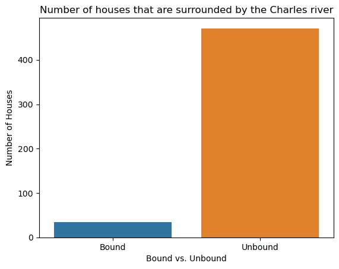

```python
inOutDict ={"Bound":[boston_df[boston_df['CHAS'] == 1.0]['CHAS'].count()],

            "Unbound":[boston_df[boston_df['CHAS'] == 0.0]['CHAS'].count()]}

inOutDf = pd.DataFrame(inOutDict)


graph2 = sb.barplot(data = inOutDf).set(xlabel = "Bound vs. Unbound", ylabel = "Number of Houses", title = "Number of houses that are surrounded by the Charles river")
```

Analysis:

- As can be seen by the chart above, the vast majority of houses in the dataset are not within the area surrounded by the Charles river.
- It might be reasonable to assume that either there was a limitation to building within that area or that the area is popular with non-residential buildings i.e. a downtown commercial area or non-retail commercial buildings. To properly determine this, more data would be required.

### Provide a boxplot for the MEDV variable vs the AGE variable.

For the following task, We were asked to split the "age" of a property into 3 catagories (x<35, 35<x<70, x<70).

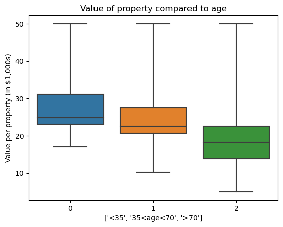

```python
age = boston_df['AGE']
boston_df.loc[(boston_df['AGE'] <= 35), 'age_group'] = 'younger than 35'
boston_df.loc[(boston_df['AGE'] > 35) & (boston_df['AGE'] < 70), 'age_group'] = 'between 35 and 70'
boston_df.loc[(boston_df['AGE'] >= 70), 'age_group'] = 'older than 70'

Less35 = boston_df[boston_df['age_group'] == 'younger than 35']['MEDV']
Between = boston_df[boston_df['age_group'] == 'between 35 and 70']['MEDV']
More70 = boston_df[boston_df['age_group'] == 'older than 70']['MEDV']

ages = [Less35,Between, More70]
ages_Dic = {"Age_Catagories":["<30","35<age<70",">70"],
                        "Age":[Less35,Between, More70]}
ages_Df=pd.DataFrame(ages_Dic)

graph3= sb.boxplot(data = ages, whis = 100).set(xlabel=['<35',"35<age<70", '>70'], ylabel = "Value per property (in \\$1,000s)", title = "Value of property compared to age")
```

### Provide a scatter plot to show the relationship between Nitric oxide concentrations and the proportion of non-retail business acres per town. What can you say about the relationship?

The variables I will need from boston_df are 'NOX' and 'INDUS'.

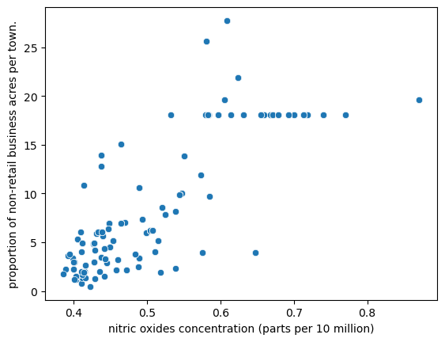

```python
nox = boston_df['NOX']
indus = boston_df['INDUS']

nox_indus_Dic = {"Nox":nox,"Indus":indus}
nox_indus_df = pd.DataFrame(nox_indus_Dic)

graph4 = sb.scatterplot(data = nox_indus_df , x="Nox", y="Indus").set(xlabel = "nitric oxides concentration (parts per 10 million)", ylabel="proportion of non-retail business acres per town.")
```

Analysis:

- As can be seen the scatter plot above shows a positive correlation between the concentration of nitric oxides and the proportion of non-retail business acres per town. In other words, if there is a larger amount of nitric oxides, it is likely that there is a greater proportion of non-retail businesses per town. There appears to be two different groups so this might be indicative of two different sources of nitric acid, but more research would need to be carried out on that front - a conclusion on that could not be reached with this plot alone.

### Create a histogram for the pupil to teacher ratio variable

The variables I will need for this task is 'PTRATIO'

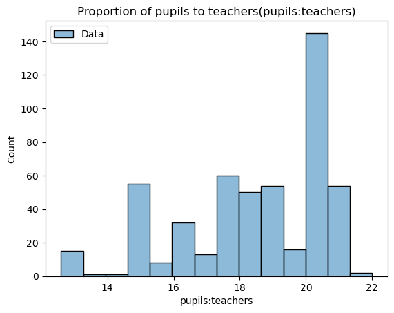

```python
ptratio = boston_df['PTRATIO']

ptratio_dic = {"Data" : ptratio}
ptratio_df = pd.DataFrame(ptratio_dic)

graph5 = sb.histplot(data =ptratio_df).set(xlabel="pupils:teachers", title=("Proportion of pupils to teachers(pupils:teachers)"))
```

Analysis:-

- The data is the average ratio of teachs and students by town. Therefore, from the graph it appears that in any particular town the ratio is likely to be higher than 15. This could be for a number of reasons - higher density in a particular town or a lack of funding for teachers - again this would need to be something that additional research would need to be conducted to deduce.

## Task 5: Use the appropriate tests to answer the questions provided.

For each of the following questions;

- Is there a significant difference in median value of houses bounded by the Charles river or not? (T-test for independent samples)
- Is there a difference in Median values of houses (MEDV) for each proportion of owner occupied units built prior to 1940 (AGE)? (ANOVA)
- Can we conclude that there is no relationship between Nitric oxide concentrations and proportion of non-retail business acres per town? (Pearson Correlation)
- What is the impact of an additional weighted distance to the five Boston employment centres on the median value of owner occupied homes? (Regression analysis)

Be sure to:

- State your hypothesis.
- Use α = 0.05
- Perform the test Statistics.
- State the conclusion from the test.

### Is there a significant difference in median value of houses bounded by the Charles river or not? (T-test for independent samples)

```python
sp.stats.levene(boston_df['MEDV'][boston_df['CHAS'] == 1.0],boston_df['MEDV'][boston_df['CHAS'] == 0.0], center = 'mean')
```

```
LeveneResult(statistic=8.75190489604598, pvalue=0.003238119367639829)
```

Analysis:-

- The results of this test are LeveneResult(statistic=8.75190489604598, pvalue=0.003238119367639829)
- The p-value < 0.05 therefore we can reject the null hypothesis that the two groups of data (where CHAS ==1.0, and CHAS ==0.0) have equal varience

```python
sp.stats.ttest_ind(boston_df['MEDV'][boston_df['CHAS'] == 1.0],boston_df['MEDV'][boston_df['CHAS'] == 0.0], equal_var=False)
```

```
Ttest_indResult(statistic=3.113291312794837, pvalue=0.003567170098137517)
```

- The results of this test are that Ttest_indResult(statistic=3.113291312794837, pvalue=0.003567170098137517)
- The p- < 0.05 therefore we can reject the null hypothesis that the fact that a house is or is not bound by the river charles has no effect on the value of the house

### Is there a difference in Median values of houses (MEDV) for each proportion of owner occupied units built prior to 1940 (AGE)? (ANOVA)

For the above question, I will need the variable MEDV and the variable AGE.

```python
sp.stats.levene(boston_df[boston_df['age_group'] == 'younger than 35']['MEDV'],
                boston_df[boston_df['age_group'] == 'between 35 and 70']['MEDV'],
                boston_df[boston_df['age_group'] == 'older than 70']['MEDV'],
                center="mean")
```

```
LeveneResult(statistic=2.7806200293748304, pvalue=0.06295337343259205)
```

The result of the above code is:- LeveneResult(statistic=2.7806200293748304, pvalue=0.06295337343259205)

As the p-value is greater than 0.05 we cannot reject the null, therefore we ought to assume that the different groups have an equal varience.

```python
Less35 = boston_df[boston_df['age_group'] == 'younger than 35']['MEDV']
Between = boston_df[boston_df['age_group'] == 'between 35 and 70']['MEDV']
More70 = boston_df[boston_df['age_group'] == 'older than 70']['MEDV']
```

```python
f_statistic, p_value = sp.stats.f_oneway(Less35,Between,More70)
print("F_Statistic: {0}, P-Value: {1}".format(f_statistic,p_value))
```

```
F_Statistic: 36.40764999196599, P-Value: 1.7105011022702984e-15
```

Since the P-Value < 0.05 we can reject the null hypothesis that the age of a building doesn't corrolate to the value of a building. In other words, the age of a property changes the value of the property.

### Can we conclude that there is no relationship between Nitric oxide concentrations and proportion of non-retail business acres per town? (Pearson Correlation)

```python
sp.stats.pearsonr(boston_df['NOX'],boston_df['INDUS'])
```

```
PearsonRResult(statistic=0.7636514469209162, pvalue=7.913361061232958e-98)
```

The p-value for this dataset is < 0.05, therefore we can reject the null hypothesis that there is not a relationship between the two vairables.

### What is the impact of an additional weighted distance to the five Boston employment centres on the median value of owner occupied homes? (Regression analysis)

For this I will need the variables DIS and MEDV. In addition, I will need to import statsmodels.api.

```python
import statsmodels.api as sm
```

```python
X = boston_df['DIS']

y= boston_df['MEDV']

X = sm.add_constant(X)

model = sm.OLS(y, X).fit()
predictions = model.predict(X)
model.summary()
```

OLS Regression Results

| Dep. Variable: | MEDV | R-squared: | 0.062 |
| --- | --- | --- | --- |
| Model: | OLS | Adj. R-squared: | 0.061 |
| Method: | Least Squares | F-statistic: | 33.58 |
| Date: | Fri, 11 Aug 2023 | Prob (F-statistic): | 1.21e-08 |
| Time: | 17:57:55 | Log-Likelihood: | -1823.9 |
| No. Observations: | 506 | AIC: | 3652. |
| Df Residuals: | 504 | BIC: | 3660. |
| Df Model: | 1 |  |  |
| Covariance Type: | nonrobust |  |  |

|  | coef | std err | t | P>\|t\| | [0.025 | 0.975] |
| --- | --- | --- | --- | --- | --- | --- |
| const | 18.3901 | 0.817 | 22.499 | 0.000 | 16.784 | 19.996 |
| DIS | 1.0916 | 0.188 | 5.795 | 0.000 | 0.722 | 1.462 |

| Omnibus: | 139.779 | Durbin-Watson: | 0.570 |
| --- | --- | --- | --- |
| Prob(Omnibus): | 0.000 | Jarque-Bera (JB): | 305.104 |
| Skew: | 1.466 | Prob(JB): | 5.59e-67 |
| Kurtosis: | 5.424 | Cond. No. | 9.32 |

Notes:  
[1] Standard Errors assume that the covariance matrix of the errors is correctly specified.